# Stat 371 Homework #5. Due Sunday Oct. 11 11:59 pm

Henry Mendoza Rivera, UW-Madison, Department of Statistics.

# 1 Problem 1: Estimating unknown population mean and proportion of success with point and interval estimators

An automobile club pays for emergency road services (ERS) requested by its members. The current policy rate the automobile club pays is based on the thought that $20\%$ of services requested will be serious mechanical problems requiring towing. However, the insurance company claims that the auto club has a higher rate of serious mechanical problems requiring towing services.

Upon examining a sample of 2927 ERS calls from the club members, the club finds that 1499 calls related to starting problems, 849 calls involved serious mechanical failures requiring towing, 498 calls involved flat tires or lockouts, and 81 calls were for other reasons.

A. Construct a $98\%$ confidence interval or by hand or step-by-step using R for the rate of all ERS calls from club members that are serious mechanical problems requiring towing services (after checking that necessary assumptions are well met).

**ANSWER: In our sample, we observed 849 of the 2927 calls were from club members that involved serious mechanical failures requiring towing. Since we have more than 5 successes (849) and more than 5 failures $(2927-849=2078)$, we believe the CLT applies and a Normal approximation is ok. We also have to assume we have a simple random sample of club calls, which we have no way to check. CI: $\hat{p} \pm z_{.02/2}*\sqrt{\frac{\hat{p}*(1-\hat{p})}{n}}$ and $\hat{p}=849/2927=0.29$ so the CI is: $0.29 \pm 2.33*\sqrt{\frac{0.29*(1-0.29)}{2927}}=0.29 \pm 2.33*0.0084=(0.2705, 0.3095)$.**

B. Using your confidence interval in part A, respond to the insurance company’s claim.

C. The club wants to construct a $95\%$ confidence interval for the rate of service requests that are related to starting problems that has a margin of error of less that 0.01. What sample size should they examine from the ERS calls from their club members if they assume a call rate of $52\%$? (They chose a value close to what they observed in their sample of 2927 calls).

**To make the margin of error less than 0.01, we first need to identify the appropriate margin of error. We can use a large sample z confidence interval for proportions to make an estimate for $\pi$: rate of service requests that are related to starting problems. $z_{.025}=1.96$ and $SE \approx \sqrt{\frac{0.52*0.48}{n}}$ so $ME \approx 1.96*\sqrt{\frac{0.52*0.48}{n}}=0.01$. Solving for $n=\frac{1.96^2*0.52*0.48}{0.01^2}=9588.634$. So $n\ge 9589$**

# 2 Problem 2

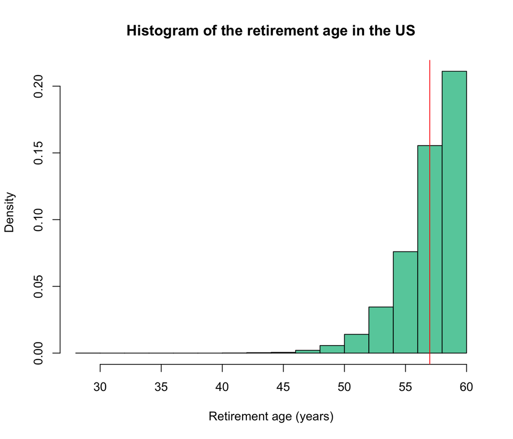

Suppose the only thing you knew about retirement age in the US is that it is left skewed. If you were to take a simple random sample of 3 US adults and compute the average and standard deviation of their retirement age, explain why it would be inappropriate to construct a $95\%$ confidence interval for the US population’s average retirement age using the Z, T, or bootstrap interval tools with $\bar{X}$.

# 3 Problem 3

Consider the tree data set in R, `trees`.(Got to Data set under the orientation module: https://canvas.wisc.edu/courses/217510/files/14870012/download?wrap=1)

A. Construct Histograms and qqplots using for all three of the quantitative variables recorded on the 31 trees. For which of the three variables do we have the strongest evidence that the population of values may not be well approximated by a normal random variable?

**From the histogram and qq plots, we have evidence that the population of Volume values of cherry trees felled for lumber is probably not normal, as our sample of data is highly right skewed.**

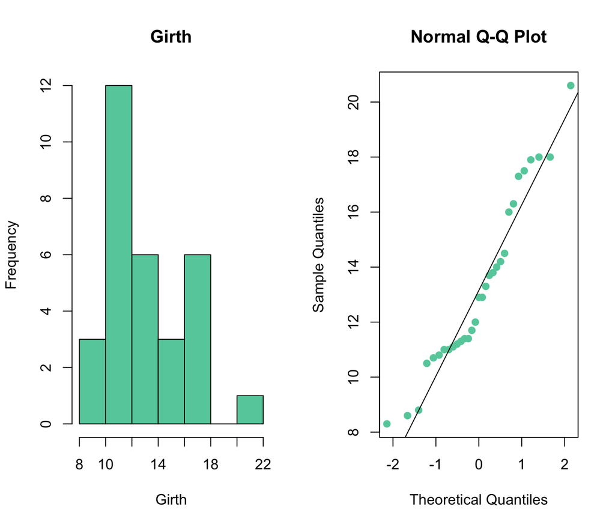

```r
par(mfrow=c(1,2))
hist(trees$Girth, main="Girth", xlab="Girth",col="aquamarine3")
qqnorm(trees$Girth,col="aquamarine3",pch=19)
qqline(trees$Girth)
```

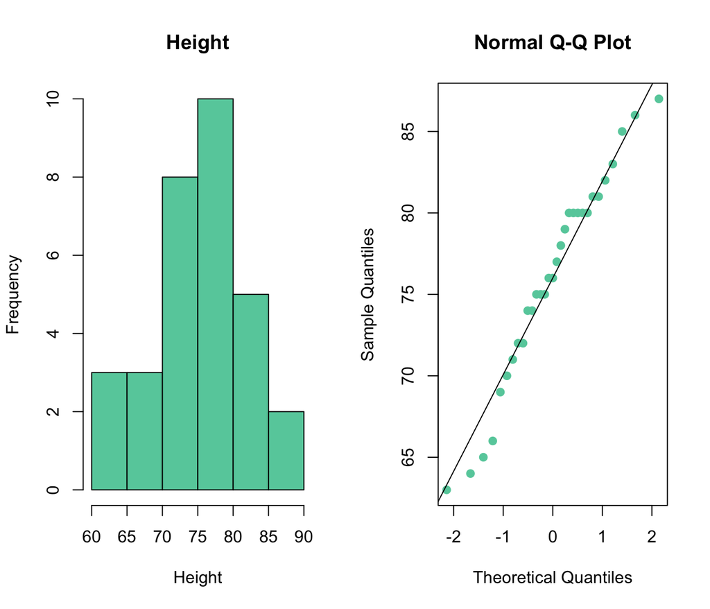

```r
par(mfrow=c(1,2))
hist(trees$Height, main="Height", xlab="Height",col="aquamarine3")
qqnorm(trees$Height,col="aquamarine3",pch=19)
qqline(trees$Height)
```

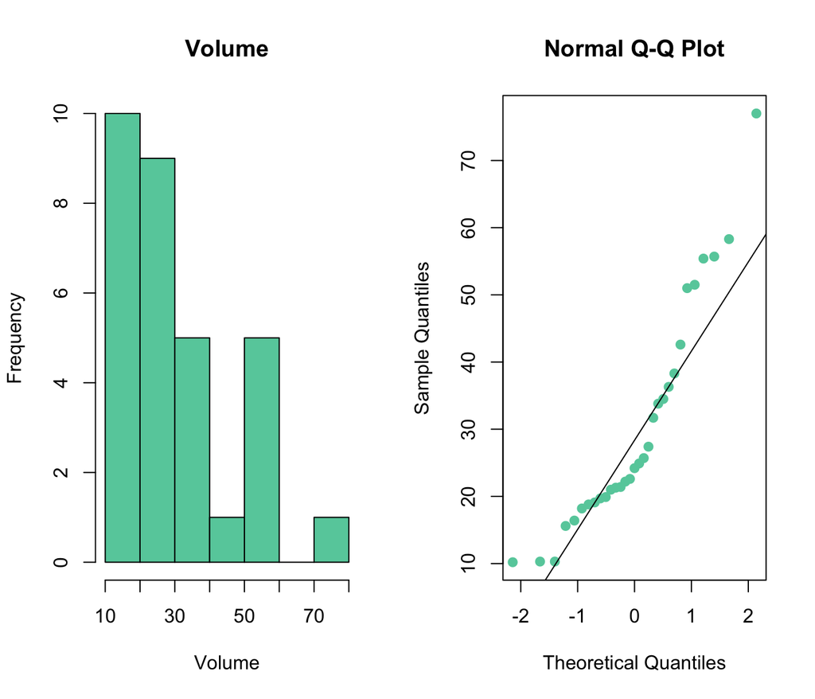

```r
par(mfrow=c(1,2))
hist(trees$Volume, main="Volume", xlab="Volume",col="aquamarine3")
qqnorm(trees$Volume,col="aquamarine3",pch=19)
qqline(trees$Volume)
```

B. Use the variables Girth and Height and construct $90\%$ t confidence intervals by hand or step-by-step using R for those variables using the sample data found in the trees data set. Summaries of the variables are given below and you can use `qt()` to find the relevant multiplier for your margin of error.

```r
summary(trees$Girth)
```

```
##    Min. 1st Qu.  Median    Mean 3rd Qu.    Max.
##    8.30   11.05   12.90   13.25   15.25   20.60
```

```r
sd(trees$Girth)
```

```
## [1] 3.138139
```

```r
length(trees$Girth)
```

```
## [1] 31
```

```r
summary(trees$Height)
```

```
##    Min. 1st Qu.  Median    Mean 3rd Qu.    Max.
##      63      72      76      76      80      87
```

```r
sd(trees$Height)
```

```
## [1] 6.371813
```

```r
length(trees$Height)
```

```
## [1] 31
```

We can use the sample averages, sample averages, and sample sizes to compute t confidence intervals for the population means. The multiplier will be 1.697 on each confidence interval since they are all at the $90\%$ level and n=31 for each group.

- Girth: $13.25 \pm 1.697*\frac{3.138}{\sqrt{31}}=(12.294,14.206)$

```r
summary(trees$Girth)
```

```
##    Min. 1st Qu.  Median    Mean 3rd Qu.    Max.
##    8.30   11.05   12.90   13.25   15.25   20.60
```

```r
sd(trees$Girth)
```

```
## [1] 3.138139
```

```r
length(trees$Girth)
```

```
## [1] 31
```

Step-by-step in R

```r
t.quantile<-qt(.95, df=30)
mean(trees$Girth)+c(-1,1)*t.quantile*sd(trees$Girth)/sqrt(length(trees$Girth))
```

```
## [1] 12.29177 14.20501
```

- Height:

```r
summary(trees$Height)
```

```
##    Min. 1st Qu.  Median    Mean 3rd Qu.    Max.
##      63      72      76      76      80      87
```

```r
sd(trees$Height)
```

```
## [1] 6.371813
```

```r
length(trees$Height)
```

```
## [1] 31
```

$76 \pm 1.697*\frac{6.372}{\sqrt{31}}=(74.058,77.942)$

Step-by-step in R

```r
t.quantile<-qt(.95, df=30)
mean(trees$Height)+c(-1,1)*t.quantile*sd(trees$Height)/sqrt(length(trees$Height))
```

```
## [1] 74.05764 77.94236
```

C. Construct the same confidence intervals that you constructed above using the `t.test()` function in R. Confirm that you get very similar values.

- Girth:

```r
t.test(trees$Girth, conf.level=0.9)
```

```
##
##  One Sample t-test
##
## data:  trees$Girth
## t = 23.506, df = 30, p-value < 2.2e-16
## alternative hypothesis: true mean is not equal to 0
## 90 percent confidence interval:
##  12.29177 14.20501
## sample estimates:
## mean of x
##  13.24839
```

- Height

```r
t.test(trees$Height, conf.level=0.9)
```

```
##
##  One Sample t-test
##
## data:  trees$Height
## t = 66.41, df = 30, p-value < 2.2e-16
## alternative hypothesis: true mean is not equal to 0
## 90 percent confidence interval:
##  74.05764 77.94236
## sample estimates:
## mean of x
##        76
```

D. Suppose this data came from 31 trees cut down by a single logger. How does that affect the conclusions we can draw? Suppose this data came from 31 trees selected at the saw mill from a variety of logging companies, how does that affect the conclusions we can draw?

**Knowing the trees were all taken by a single logger means I would only feel comfortable make an inference about the average values of trees that that logger selects. Knowing the trees were all taken by from a single mill, I would only feel comfortable make an inference about the average values of trees that that mill collects/its loggers supply. We need to consider what population we have a simple random sample from and only make inferences about that population’s parameter**

E. Construct $90\%$ Bootstrap T Confidence intervals for $\mu_G$, and $\mu_H$ (G: Girt, H:Height) from the sample data in the `trees` data set. Compare these confidence intervals to those you computed in Part B and part C and brainstorm possible reasons reasons for the relationships you noticed. (Note, you will need to include the bootstrap function code [~12 lines starting with “bootstrap=function(…)” from the notes] within your .Rmd file in order for R Markdown to find it when you Knit.)

**The bootstrap and t confidence intervals for girth were very similar while the t confidence interval was wider than that of the bootstrap for the height data. Because the normality assumption for the t confidence interval (sample size large enough that $\bar{X} \approx N$) appears to be reasonably met for both girth and height, I will report the t confidence interval. It is more standard and slightly more conservative.**

```r
bootstrap=function(x,n.boot){
  n<-length(x)
  x.bar<-mean(x)
  t.hat<-rep(0, n.boot) #create vector that we will fill with generated "t" value
  for (i in 1:n.boot){
    x.star<-sample(x, size=n, replace=TRUE)
    x.bar.star<-mean(x.star)
    s.star<-sd(x.star)
    t.hat[i]<-(x.bar.star-x.bar)/(s.star/sqrt(n))
  }
return(t.hat)
}

set.seed(1)
girth<-trees$Girth
girth.boot<-bootstrap(girth, n.boot=30000)
g.lower.t<-quantile(girth.boot, probs=0.05)
g.upper.t<-quantile(girth.boot, probs=0.95)
g.xbar=mean(girth)
g.s=sd(girth)
g.approxSE=g.s/sqrt(length(girth))

g.xbar-g.lower.t*g.approxSE  #14.26
```

```
##       5%
## 14.26391
```

```r
g.xbar-g.upper.t*g.approxSE  #12.35
```

```
##      95%
## 12.34798
```

```r
set.seed(1)
height<-trees$Height
height.boot<-bootstrap(height, n.boot=30000)
h.lower.t<-quantile(height.boot, probs=0.05)
h.upper.t<-quantile(height.boot, probs=0.95)
h.xbar=mean(height)
h.s=sd(height)
h.approxSE=g.s/sqrt(length(height))

h.xbar-h.lower.t*h.approxSE  #74.998
```

```
##       5%
## 76.91331
```

```r
h.xbar-h.upper.t*h.approxSE  #76.91
```

```
##      95%
## 75.00078
```

F. Suppose the 31 trees in the `trees` data set is a simple random sample from those at a saw mill. The mill would like to use this sample to estimate the proportion of trees that they have at their mill with Volume over 65 cubic ft. Use the following code to determine what count of trees in this sample have Volume over 65 cubic ft. Then, explain why they should not do a large-sample z confidence interval for the proportion of trees at their mill with Volume over 65 cubic feet with this sample of 31 trees. (`Hint:` Consider what assumption for our large sample Z confidence interval for $\pi$ is not well met.)

```r
sum(trees$Volume>65)
```

```
## [1] 1
```

**31 is not a very large sample size. In order for the normal approximation for $\hat{p}$ to be good, we would want $n*\hat{p} \ge 5$ and $n*(1-\hat{p}) \ge 5$. This is not true for this sample. They should consider taking a larger sample from their stockyard.**